# Censored Data Analysis HW 3

Samuel Messa

November 24, 2019

## Data prep

The datasets which wil be the subject of our analysis contain mortality data from the Czech Republic in the year 2013 for males and females. Each dataframe has three columns:

- $i$, representing the age group (going from the age $i$ years to $i+1$ years)
- $Di$ representing the number of deaths in the age group in 2013
- $Yi$ representing the number of people alive when they reached the age $i$

We begin by loading necessary libraries and the datasets.

```r
load(url("http://karlin.mff.cuni.cz/~vavraj/cda/data/mort.RData"))
library(httr)
library(survival)
library(tidyverse)
library(ggpubr)
library(magrittr)
library(knitr)
library(KMsurv)
library(readxl)
```

# Task 1

First, we construct the Nelson-Aalen and Kaplan-Meier estimates for males and females. The logic behind their construction is analogous to previous assignments.

```r
mort.f %<>% mutate(
  cumYi = Yi %>% rev() %>% cumsum() %>% rev(),
  ratio = Di/cumYi,
  NA_i = ratio %>% cumsum(),
  KM_i = (1-ratio) %>% cumprod(),
  censored = Yi - Di,
  gender = "female"
)
mort.m %<>% mutate(
  cumYi = Yi %>% rev() %>% cumsum() %>% rev(),
  ratio = Di/cumYi,
  NA_i = ratio %>% cumsum(),
  KM_i = (1-ratio) %>% cumprod(),
  censored = Yi - Di,
  gender = "male"
)
mort <- rbind(mort.f,mort.m)
```

The Kaplan-Meier estimates can are visualized in the figure below.

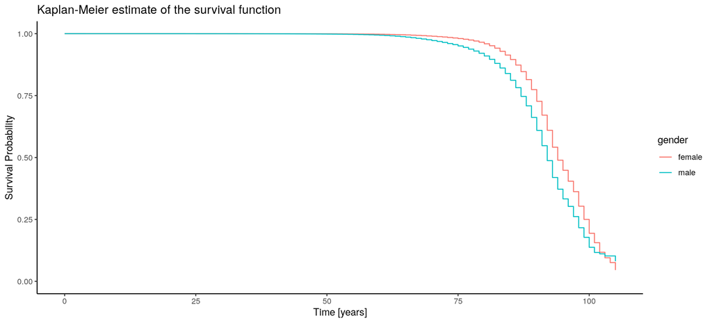

```r
mort %>%
  ggplot() +
  geom_step(mapping = aes(x = i, y = KM_i, color = gender)) +
  expand_limits(y = c(0,1)) +
  theme_classic() +
  xlab("Time [years]") +
  ylab("Survival Probability") +
  ggtitle("Kaplan-Meier estimate of the survival function")
```

Next we construct the actuarial estimates of the survival function.

```r
act_estimate_female <- mort %>%
  filter(gender == "female") %$%
  lifetab(tis = c(i,106), ninit = cumYi[1],nlost = censored,nevent = .$Di) %>%
  mutate(gender = "female",i = 0:105)
act_estimate_male <- mort %>%
  filter(gender == "male") %$%
  lifetab(tis = c(i,106), ninit = cumYi[1],nlost = censored,nevent = .$Di) %>%
  mutate(gender = "male",i = 0:105)
act_estimate <- rbind(act_estimate_female,act_estimate_male)
```

And plot the results

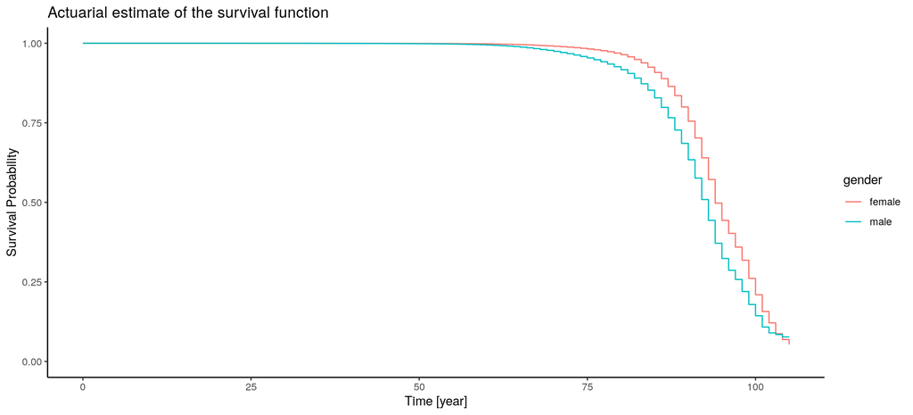

```r
act_estimate %>%
  ggplot() +
  geom_step(mapping = aes(x = i, y = surv, color = gender)) +
  expand_limits(y = c(0,1)) +
  theme_classic() +
  xlab("Time [year]") +
  ylab("Survival Probability") +
  ggtitle("Actuarial estimate of the survival function")
```

Visualizing both of the estimates gets us to the following figure:

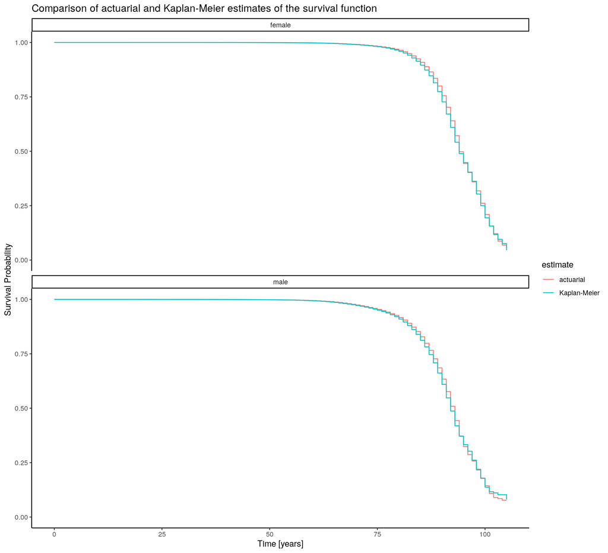

```r
estimates <- rbind(
  act_estimate %>% transmute(time = i, surv = surv, estimate = "actuarial",gender = gender),
  mort %>% transmute(time = i, surv = KM_i, estimate = "Kaplan-Meier", gender = gender)
  )
estimates %>%
  ggplot() +
  geom_step(mapping = aes(x = time, y = surv, color = estimate)) +
  expand_limits(y = c(0,1)) +
  theme_classic() +
  xlab("Time [years]") +
  ylab("Survival Probability") +
  ggtitle("Comparison of actuarial and Kaplan-Meier estimates of the survival function") +
  facet_wrap( ~gender ,nrow  = 2)
```